# 677 HW

Jingning Yang

4/6/2020

## Exercise 8.1

```r
# install.packages("rjags")
# install.packages("runjags")
require(rjags)
source("Jags-Ydich-XnomSsubj-MbernBeta.R")
```

```
##
## Kruschke, J. K. (2015). Doing Bayesian Data Analysis, Second Edition:
## A Tutorial with R, JAGS, and Stan. Academic Press / Elsevier.
```

```r
#3 subjects
myData <- read.csv("file.csv")
y = myData$y
s = as.numeric(myData$s)
Ntotal = length(y)
Nsubj = length(unique(s))
dataList = list(y=y,s=s,Ntotal = Ntotal , Nsubj = Nsubj)

modelString = "
model {
  for ( i in 1:Ntotal ) {
    y[i] ~ dbern( theta )
  }
  theta ~ dbeta( 2 , 2 )
}
"
writeLines( modelString , con="TEMPmodel.txt" )

# Generate the MCMC chain:
mcmcCoda = genMCMC(data=myData , numSavedSteps=10000)
```

```
##
##
## Burning in the MCMC chain...
## Sampling final MCMC chain...
```

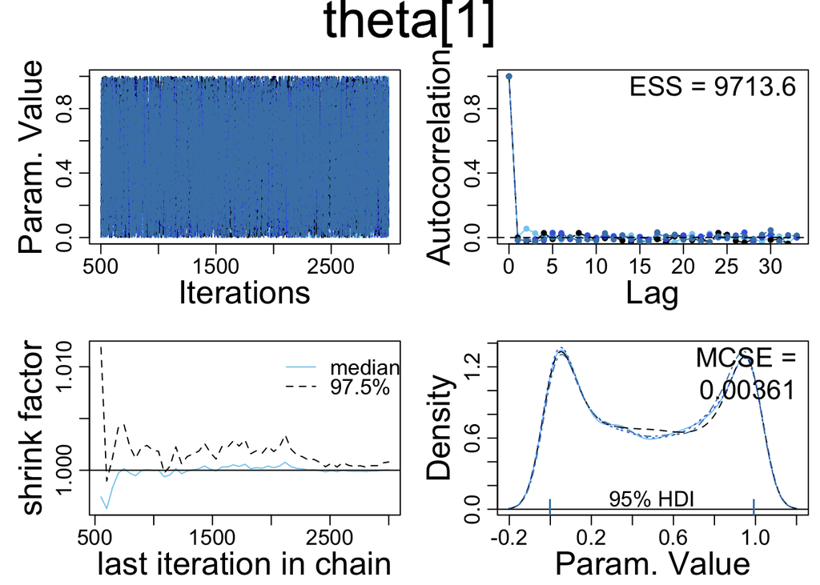

```
##                           Mean        Median         Mode     ESS HDImass
## theta[1]           0.496013393  4.940010e-01  0.039264480 10000.0    0.95
## theta[2]           0.500645720  5.011839e-01  0.960846066 10000.0    0.95
## theta[3]           0.497317280  4.928709e-01  0.038955583 10000.0    0.95
## theta[1]-theta[2] -0.004632326 -3.735230e-03 -0.002269797 10000.0    0.95
## theta[1]-theta[3] -0.001303886 -3.159215e-05  0.002166312 10000.0    0.95
## theta[2]-theta[3]  0.003328440  2.500276e-03  0.007133829 10253.5    0.95
##                          HDIlow   HDIhigh CompVal PcntGtCompVal ROPElow
## theta[1]           1.614212e-08 0.9929169      NA            NA      NA
## theta[2]           3.364117e-09 0.9941839      NA            NA      NA
## theta[3]           1.611338e-07 0.9941158      NA            NA      NA
## theta[1]-theta[2] -9.410996e-01 0.9033444       0         49.37      NA
## theta[1]-theta[3] -9.995375e-01 0.8486054       0         50.00      NA
## theta[2]-theta[3] -9.347084e-01 0.9112181       0         50.48      NA
##                   ROPEhigh PcntLtROPE PcntInROPE PcntGtROPE
## theta[1]                NA         NA         NA         NA
## theta[2]                NA         NA         NA         NA
## theta[3]                NA         NA         NA         NA
## theta[1]-theta[2]       NA         NA         NA         NA
## theta[1]-theta[3]       NA         NA         NA         NA
## theta[2]-theta[3]       NA         NA         NA         NA
```

[output not shown]

```r
# Display diagnostics of chain, for specified parameter:
diagMCMC( mcmcCoda , parName="theta[1]" )
# Display numerical summary statistics of chain:
smryMCMC( mcmcCoda , compVal=NULL , compValDiff=0.0 )
```

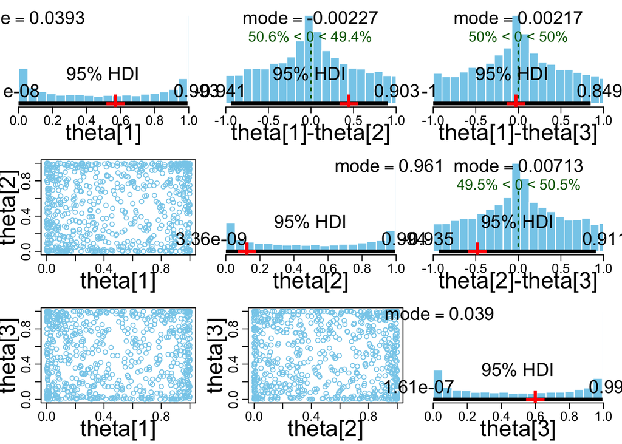

```r
# Display graphical posterior information:
plotMCMC( mcmcCoda , data=myData , compVal=NULL , compValDiff=0.0 )

# #2 subjects
# mydata <- read.csv("file1.csv")
# y = mydata$y
# s = as.numeric(mydata$s)
# Ntotal = length(y)
# Nsubj = length(unique(s))
# dataList = list(y=y,s=s,Ntotal = Ntotal, Nsubj = Nsubj)
#
# modelString = "
# model {
#   for ( i in 1:Ntotal ) {
#     y[i] ~ dbern( theta )
#   }
#   theta ~ dbeta( 2 , 2 )
# }
# "
# writeLines(modelString , con="TEMPmodel.txt")
#
# # Generate the MCMC chain:
# mcmcCoda = genMCMC(data=mydata, numSavedSteps=10000)
# # Display diagnostics of chain, for specified parameter:
# diagMCMC( mcmcCoda , parName="theta[1]" )
# # Display numerical summary statistics of chain:
# smryMCMC( mcmcCoda , compVal=NULL , compValDiff=0.0 )
# # Display graphical posterior information:
# plotMCMC( mcmcCoda , data=myData , compVal=NULL , compValDiff=0.0 )
```

## Exercise 8.2

```r
# data <- read.csv("Jags-Ydich-XnomSsubj-MbernBeta-Example.R")
# y = data$y
# s = as.numeric(data$s)
# Ntotal = length(y)
# Nsubj = length(unique(s))
# dataList = list(y=y,s=s,Ntotal = Ntotal, Nsubj = Nsubj)
#
# modelString = "
# model {
#   for ( i in 1:Ntotal ) {
#     y[i] ~ dbern( theta )
#   }
#   theta ~ dbeta( 2 , 2 )
# }
# "
# writeLines(modelString , con="TEMPmodel.txt")

# Generate the MCMC chain:
summaryInfo = smryMCMC( mcmcCoda , compVal=0.5 , rope=c(0.45,0.55) ,
                        compValDiff=0.0 , ropeDiff = c(-0.05,0.05) )
```

```
##                           Mean        Median         Mode     ESS HDImass
## theta[1]           0.496013393  4.940010e-01  0.039264480 10000.0    0.95
## theta[2]           0.500645720  5.011839e-01  0.960846066 10000.0    0.95
## theta[3]           0.497317280  4.928709e-01  0.038955583 10000.0    0.95
## theta[1]-theta[2] -0.004632326 -3.735230e-03 -0.002269797 10000.0    0.95
## theta[1]-theta[3] -0.001303886 -3.159215e-05  0.002166312 10000.0    0.95
## theta[2]-theta[3]  0.003328440  2.500276e-03  0.007133829 10253.5    0.95
##                          HDIlow   HDIhigh CompVal PcntGtCompVal ROPElow
## theta[1]           1.614212e-08 0.9929169     0.5         49.66    0.45
## theta[2]           3.364117e-09 0.9941839     0.5         50.08    0.45
## theta[3]           1.611338e-07 0.9941158     0.5         49.54    0.45
## theta[1]-theta[2] -9.410996e-01 0.9033444     0.0         49.37   -0.05
## theta[1]-theta[3] -9.995375e-01 0.8486054     0.0         50.00   -0.05
## theta[2]-theta[3] -9.347084e-01 0.9112181     0.0         50.48   -0.05
##                   ROPEhigh PcntLtROPE PcntInROPE PcntGtROPE
## theta[1]              0.55      47.49       6.06      46.45
## theta[2]              0.55      46.95       6.26      46.79
## theta[3]              0.55      47.51       6.00      46.49
## theta[1]-theta[2]     0.05      44.92      10.64      44.44
## theta[1]-theta[3]     0.05      44.26      11.45      44.29
## theta[2]-theta[3]     0.05      44.00      11.08      44.92
```

The output will differ in the numerical details because of randomness in the MCMC chain. Although the output includes many decimal places, most are not significant because of the sampling randomness in the MCMC chain; only the first few digits are stable, depending on the ESS.

Each row corresponds to the parameter or parameter difference indicated in the left-most column. The columns labelled Mean, Median, and Mode are the corresponding values of the MCMC chain for that parameter. The ESS is the effective sample size, which is the chain length divided by the autocorrelation, as defined in the book. The next three columns indicate the probability mass of the HDI (which here is the default of 95%), the lower limit of the HDI, and the upper limit. Next is the comparison value (CompVal) for single-parameter decisions, which was specified in the argument as 0.5. The next column indicates the percentage of the posterior that is greater than the comparison value (PcntGtCompVal). Next are the columns for the ROPE, which repeat the specifications in the arguments. The final three columns indicate the percentage of the posterior distribution that is less than the ROPE lower limit, within the ROPE limits, and greater than the ROPE upper limit.

## Exercise 8.3

```r
# fileNameRoot = "Jags-Ydich-XnomSsubj-MbernBeta-"
# graphFileType = "eps"
# # Generate the MCMC chain:
# mcmcCoda = genMCMC( data=myData , numSavedSteps=50000 , saveName=fileNameRoot )
# # Display diagnostics of chain, for specified parameters:
# parameterNames = varnames(mcmcCoda) # get all parameter names
# for ( parName in parameterNames ) {
#   diagMCMC( codaObject=mcmcCoda , parName=parName ,
#                 saveName=fileNameRoot , saveType=graphFileType )
# }
# # Get summary statistics of chain:
# summaryInfo = smryMCMC( mcmcCoda , compVal=0.5 , rope=c(0.45,0.55) ,
#                         compValDiff=0.0 , ropeDiff = c(-0.05,0.05) ,
#                         saveName=fileNameRoot )
# # Display posterior information:
# plotMCMC( mcmcCoda , data=myData , compVal=NULL , #rope=c(0.45,0.55) ,
#           compValDiff=0.0 , #ropeDiff = c(-0.05,0.05) ,
#           saveName=fileNameRoot , saveType=graphFileType )
```

Files “Jags-Ydich-XnomSsubj-MbernBeta-Mcmc.Rdata”,“Jags-Ydich-XnomSsubj-MbernBeta-Diagtheta[1].eps”, “Jags-Ydich-XnomSsubj-MbernBeta-Diagtheta[2].eps”, “Jags-Ydich-XnomSsubj-MbernBeta-Diagtheta[3].eps”, “Jags-Ydich-XnomSsubj-MbernBeta-Summaryinfo.csv” and “Jags-Ydich-XnomSsubj-MbernBeta-Post.eps” are created in my working directory.  
The first line above specifies the beginning of the filenames for saved information, and the second line above specifies the graphics format for saved graphs.  
The MCMC chain is saved in a file named Jags-Ydich-XnomSsubj-MbernBeta-Mcmc.Rdata. Notice the name is the fileNameRoot with Mcmc appended. It is in compressed Rdata format.  
The diagnostic graphs are saved in files named Jags-Ydich-XnomSsubj-MbernBeta-Diagtheta[1].eps and Jags-Ydich-XnomSsubj-MbernBeta-Diagtheta[2].eps Notice the names are the fileNameRoot with Diag appended.  
The summary information is saved in a file named Jags-Ydich-XnomSsubj-MbernBeta-SummaryInfo.csv which is in comma-separated-value format. Notice the name is the fileNameRoot with SummaryInfo appended.  
The graph of the posterior distribution is saved in a file named Jags-Ydich-XnomSsubj-MbernBeta-Post.eps Notice the name is the fileNameRoot with Post appended.

## Exercise 8.4

```r
# # Optional generic preliminaries:
# graphics.off() # This closes all of R's graphics windows.
# rm(list=ls())  # Careful! This clears all of R's memory!
# myData = read.csv("file1.csv")
# source("Jags-Ydich-XnomSsubj-MbernBeta.R")
# fileNameRoot = "Jags-Ydich-XnomSsubj-MbernBeta-"
# graphFileType = "eps"
# mcmcCoda = genMCMC( data=myData , numSavedSteps=50000 , saveName=fileNameRoot )
# parameterNames = varnames(mcmcCoda) # get all parameter names
# for ( parName in parameterNames ) {
#   diagMCMC( codaObject=mcmcCoda , parName=parName ,
#             saveName=fileNameRoot , saveType=graphFileType )
# }
# # Get summary statistics of chain:
# summaryInfo = smryMCMC( mcmcCoda , compVal=NULL , #rope=c(0.45,0.55) ,
#                         compValDiff=0.0 , #ropeDiff = c(-0.05,0.05) ,
#                         saveName=fileNameRoot )
# # Display posterior information:
# plotMCMC( mcmcCoda , data=myData , compVal=NULL , #rope=c(0.45,0.55) ,
#           compValDiff=0.0 , #ropeDiff = c(-0.05,0.05) ,
#           saveName=fileNameRoot , saveType=graphFileType )
```

```r
# # Optional generic preliminaries:
# graphics.off() # This closes all of R's graphics windows.
# rm(list=ls())  # Careful! This clears all of R's memory!
# myData = read.csv("file1.csv")
# source("Jags-Ydich-XnomSsubj-MbernBeta.R")
# fileNameRoot = "Jags-Ydich-XnomSsubj-MbernBeta-"
# graphFileType = "eps"
# mcmcCoda = genMCMC( data=myData , numSavedSteps=50000 , saveName=fileNameRoot )
# parameterNames = varnames(mcmcCoda) # get all parameter names
# for ( parName in parameterNames ) {
#   diagMCMC( codaObject=mcmcCoda , parName=parName ,
#             saveName=fileNameRoot , saveType=graphFileType )
# }
# # Get summary statistics of chain:
# summaryInfo = smryMCMC( mcmcCoda , compVal=NULL , #rope=c(0.45,0.55) ,
#                         compValDiff=0.0 , #ropeDiff = c(-0.05,0.05) ,
#                         saveName=fileNameRoot )
# # Display posterior information:
# plotMCMC( mcmcCoda , data=myData , compVal=NULL , #rope=c(0.45,0.55) ,
#           compValDiff=0.0 , #ropeDiff = c(-0.05,0.05) ,
#           saveName=fileNameRoot , saveType=graphFileType )
```

In the file Jags-Ydich-XnomSsubj-MbernBeta.R, change the specification of the prior to dbeta(1,1) in line 36, then we run the script Jags-Ydich-XnomSsubj-MbernBeta-Example.R.

```r
# # Optional generic preliminaries:
# graphics.off() # This closes all of R's graphics windows.
# rm(list=ls())  # Careful! This clears all of R's memory!
# myData = read.csv("file1.csv")
# source("Jags-Ydich-XnomSsubj-MbernBeta.R")
# fileNameRoot = "Jags-Ydich-XnomSsubj-MbernBeta-"
# graphFileType = "eps"
# mcmcCoda = genMCMC( data=myData , numSavedSteps=50000 , saveName=fileNameRoot )
# parameterNames = varnames(mcmcCoda) # get all parameter names
# for ( parName in parameterNames ) {
#   diagMCMC( codaObject=mcmcCoda , parName=parName ,
#             saveName=fileNameRoot , saveType=graphFileType )
# }
# # Get summary statistics of chain:
# summaryInfo = smryMCMC( mcmcCoda , compVal=NULL , #rope=c(0.45,0.55) ,
#                         compValDiff=0.0 , #ropeDiff = c(-0.05,0.05) ,
#                         saveName=fileNameRoot )
# # Display posterior information:
# plotMCMC( mcmcCoda , data=myData , compVal=NULL , #rope=c(0.45,0.55) ,
#           compValDiff=0.0 , #ropeDiff = c(-0.05,0.05) ,
#           saveName=fileNameRoot , saveType=graphFileType )
```